# WIOT Model in R

Sun Ye

2017/8/28

# 1 Introduction

This .html file is a brief demonstration of the previous work of Zhi Wang, Shang-Jin Wei, Xinding Yu, Kunfu Zhu entitled **Measures of Participation in Global Value Chains and Global Business Cycles**. WIOD Data, 2016 Release (see http://www.wiod.org/release16) is used in R studio.

# 2 Cross-sectional decomposition using the data of 2000

## 2.1 Include dataset & packages

```r
## Dataset
chr1 = "WIOT"
chr2 = "_October16_ROW.RData"
datatemp = paste(chr1,2000:2014,chr2,sep = "")
temploop = 1
load(datatemp[temploop])
N <- 44;
n <- 56;
```

```r
## Pakages
library(Matrix)
library(ggplot2)
library(abind)
library(dplyr)
library(reshape2)
library(plm)
```

Packages used in this file are *Matrix*, *ggplot2*, *abind*. *Matrix* is used for dgCMatrix-class and large block matrices. *ggplot2* is for the data visualization. And *abind* allows to concatenate matrices in to multidimensional arrays unlimitedly.

## 2.2 Calculate basic matrices

```r
## Calculate Coefficient Matrix A for Intermediate Production
X <- wiot[wiot$IndustryCode=="GO",]
X <- X[, seq(1,N*n)+5]
Z <- data.matrix(wiot[seq(1,N*n), seq(1,N*n)+5])
A <- Z/kronecker(matrix(1,N*n,1), t(as.numeric(X)))
A[is.nan(A)] <- 0
A <- as(A, "dgCMatrix")

## Decompose the A Matrix into Ad (Domestic) and Af (Foreign)
A_diag <- replicate(N, kronecker(matrix(1,n,n), 1), simplify=FALSE)
AA_diag <- bdiag(A_diag)
Ad <- AA_diag * A
Af <- as(as.matrix(A - Ad), "dgCMatrix")

## Calculate Coefficient Vector V for Value-Added Entries
Va <- X - apply(Z, 2, sum)
V <- Va / X
V[is.nan(as.matrix(V))] <- 0

## Generate the Diagnal of V: Vhat
Vhat <- Diagonal(N*n,x = as.numeric(V))

## Calculate Final Consumption Matrix Y, (Ylist in the Code)
Ypart <- data.matrix(wiot[seq(1, N*n), seq(N*n+1, N*n+N*5) + 5])
Ylist <- c()
for(i in 1:N){Ylist<-cbind(Ylist, apply(Ypart[, seq(i*5-4,i*5)], 1, sum))}

## Decompose the Matrix Y into Yd (Domestic) and Yf (Foreign)
Ylist1 <- kronecker(matrix(1, N*n, N), 0)
for(i in 1:N){Ylist1[seq((i-1)*n+1, i*n), i]<-Ylist[seq((i-1)*n+1, i*n), i]}
Ylist2 <- Ylist-Ylist1

## Generate the Diagnal of Yd, Yf and Y: Ydhat and Yfhat
Yhat <- Diagonal(N*n,apply(Ylist, 1, sum))
Ydhat <- Diagonal(N*n,apply(Ylist1, 1, sum))
Yfhat <- Diagonal(N*n,apply(Ylist2, 1, sum))
rm(Ylist, Ylist1, Ylist2, Ypart, A_diag, AA_diag, Z, X, V)
```

For detailed demonstration of this methodology, please refer to the paper (http://www.nber.org/papers/w23222.pdf).

## 2.3 Decomposition of value added and final consumption

```r
B <- solve(Diagonal(N*n)-A)
L <- solve(Diagonal(N*n)-Ad)
VBY <- as.matrix(Vhat%*%B%*%Yhat)
V_D <- as.matrix(Vhat%*%L%*%Ydhat)
V_R <- as.matrix(Vhat%*%L%*%Yfhat)
V_GVC_S <- as.matrix(Vhat%*%L%*%Af%*%L%*%Ydhat)
V_GVC_C <- as.matrix(Vhat%*%L%*%Af%*%(B%*%Yhat-L%*%Ydhat))
```

Again, refer to the paper for demonstration.

## 2.4 Backward linkage and forward linkage

```r
B_link <- matrix(apply(V_GVC_S+V_GVC_C, 2, sum)/apply(VBY, 2, sum), nrow = n, ncol = N)
F_link <- matrix(apply(V_GVC_S+V_GVC_C, 1, sum)/apply(VBY, 1, sum), nrow = n, ncol = N)
```

- Forward Industrial Linkage measures domestic value added generated from GVCs production and trade activities as a share of total sector value added (GDP);
- Backward Industrial Linkage measures the percentage of a country’s final goods production contributed by both domestic and foreign factors that involve cross country production sharing activities.

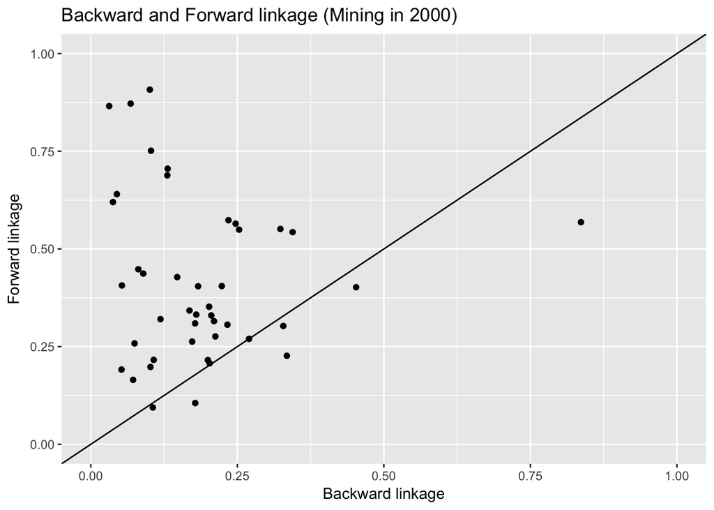

```r
## A Brief Look at Mining Sector
qplot(B_link[4,], F_link[4,], xlim = c(0,1), ylim = c(0,1), xlab = "Backward linkage", ylab = "Forward linkage", main = "Backward and Forward linkage (Mining in 2000)") + geom_abline(intercept = 0, slope = 1)
```

Apart from sector-wise perspective, we can also have a look at the country-wise situation where “country” is held fixed.

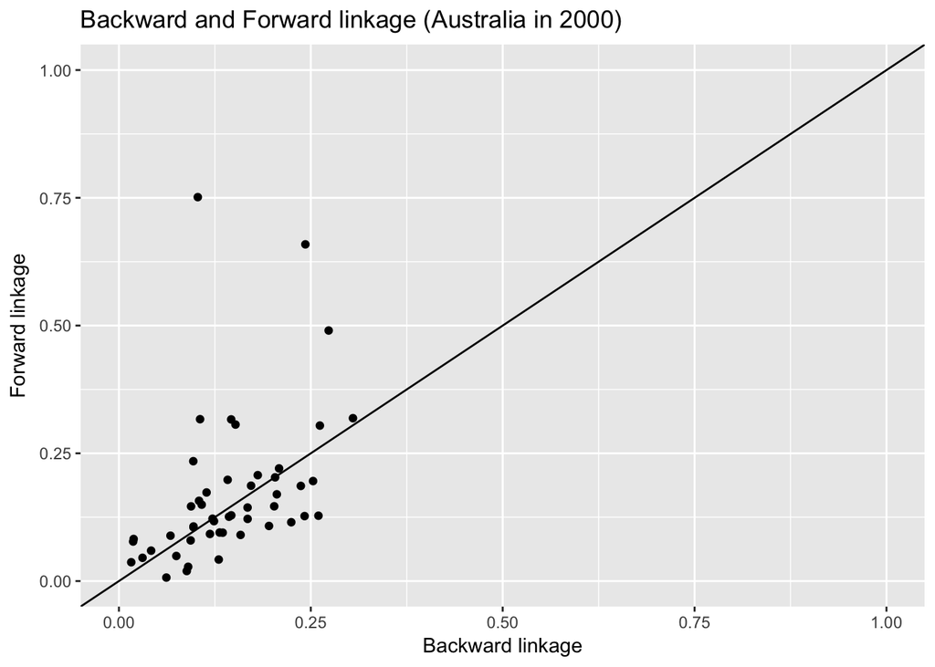

```r
## A Brief Look at Australia
qplot(B_link[,1], F_link[,1], xlim = c(0,1), ylim = c(0,1), xlab = "Backward linkage", ylab = "Forward linkage", main = "Backward and Forward linkage (Australia in 2000)") + geom_abline(intercept = 0, slope = 1)
```

# 3 Adding the axis of time

## 3.1 Data rearrangement

```r
## Loop 10 years' data
#p <- 0
#temploop <- 2
## wiot.R is a previously saved .R file to operate a loop for data from 10 #years, identical with the code presented in the above except for some minor #modifications. p here is an operational parameters in "wiot.R"
#source("wiot.R")
#p <- 1
#for(temploop in 3:15){source("wiot.R")}

## Reshape and Rearrangment
### Forward
#fv <- as.vector(t(apply(VBY,c(1,2),sum)))
#fd <- as.vector(t(apply(V_D,c(1,2),sum)))
#fr <- as.vector(t(apply(V_R,c(1,2),sum)))
#fs <- as.vector(t(apply(V_GVC_S,c(1,2),sum)))
#fc <- as.vector(t(apply(V_GVC_C,c(1,2),sum)))
#### Backward
#bv <- as.vector(t(apply(VBY,c(1,3),sum)))
#bd <- as.vector(t(apply(V_D,c(1,3),sum)))
#br <- as.vector(t(apply(V_R,c(1,3),sum)))
#bs <- as.vector(t(apply(V_GVC_S,c(1,3),sum)))
#bc <- as.vector(t(apply(V_GVC_C,c(1,3),sum)))
#### Concatenation
#decomposition <- cbind(fv, fd, fr, fs, fc, bv, bd, br, bs, bc)
#decomposition <- data.frame(decomposition)
#decomposition <- cbind(Country=rep(wiot$Country[seq(1,N*n)],15), #Sector=rep(wiot$RNr[seq(1,N*n)],15), Year=rep(2000:2014,each #=N*n),decomposition)
#save(decomposition, file = "decomposition.Rdata")
### Finish Decomposition with Time Series Data
```

The output contains four 3-Dimensional arrays, each representing V_D, V_R, V_GVC_C, V_GVC_S respectively, consisting data covering 15 years, 44 regions and 56 sectors. Now we can use these data for further econometrical analysis.

## 3.2 Linkage variation along with the time

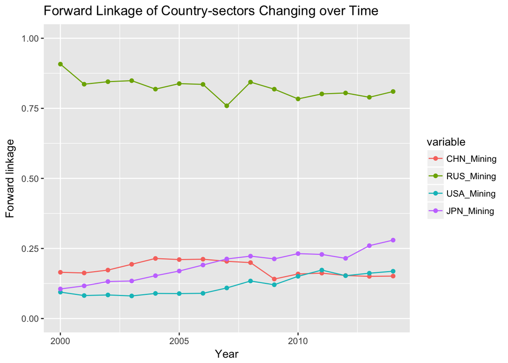

```r
load("decomposition.Rdata")
decomposition <- decomposition %>%
  mutate(fl=(fs+fc)/fv) %>%
  mutate(bl=(bs+bc)/bv)
fl_matrix <- matrix(data = decomposition$fl, nrow = 15, ncol = N*n, byrow = TRUE)
bl_matrix <- matrix(data = decomposition$bl, nrow = 15, ncol = N*n, byrow = TRUE)
sampleplot <- cbind(Year=2000:2014,CHN_Mining = fl_matrix[,396],RUS_Mining = fl_matrix[,2020],USA_Mining = fl_matrix[,2356],JPN_Mining = fl_matrix[,1348])
sampleplot <- melt(data.frame(sampleplot), "Year")
qplot(Year, value, data = sampleplot, geom = c("path","point"), colour = variable, ylim = c(0,1), xlab = "Year", ylab = "Forward linkage", main = "Forward Linkage of Country-sectors Changing over Time")
```

By grouping different sorts of value added, and analysing jointly, we can plot the trend of proportion of different sorts of value added changing over time.

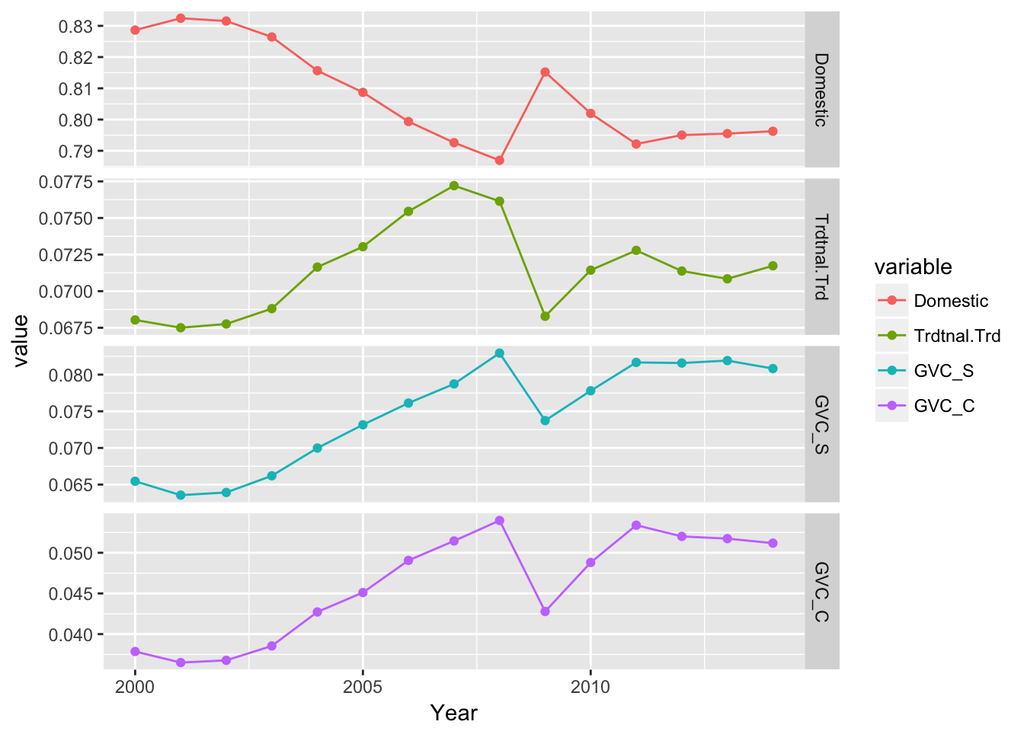

```r
grp_res <- decomposition %>%
  group_by(Year) %>%
  summarize(Domestic = sum(fd)/sum(fv), Trdtnal.Trd = sum(fr)/sum(fv), GVC_S = sum(fs)/sum(fv), GVC_C = sum(fc)/sum(fv))
grp_res<-melt(grp_res, "Year")
ggplot(grp_res, ylab = "Forward linkage") +
  geom_line(aes(x = Year, y = value, colour = variable)) +
  geom_point(aes(x = Year, y = value, colour = variable)) +
  facet_grid(variable ~ ., scales = 'free_y')
```

## 3.3 Econometric Analysis